# DE of Ibrutinib and Duvelisib, pre-processed with STAR + HTSeq

### 3.3.2 Create resulting data frames

Create data frame

```r
load("./output/DEresShrinkIbrDuv_allbatches_STAR_patIDcondi_scTransform_20220512.RData")

allResdf <- lapply(allResShrink, function(res) {
  resTab <- data.frame(res@listData) %>%
      rownames_to_column(var = "Ensembl") %>%
      mutate(symbol = rowData(ddsDrug)[Ensembl,]$symbol) %>%
      mutate(chromosome = rowData(ddsDrug)[Ensembl,]$chromosome) %>%
      mutate(padjBH = p.adjust(.data$pvalue, method="BH"))

  names(resTab)[names(resTab) == "log2FoldChange"] <- "LFC"
  resTab_final <- resTab
})
names(allResdf) <- allTreat

allResdf$Ibrutinib <- mutate(allResdf$Ibrutinib, treatment="Ibrutinib")
allResdf$Duvelisib <- mutate(allResdf$Duvelisib, treatment="Duvelisib")
```

Combine all data frames

```r
# Add treatment info to column names
colname <- c("Ibr", "Duv")
name <- 0

allResdf.names <- lapply(allResdf, function(df) {
  name <<- name + 1
  colnames(df) <- paste(colnames(df),colname[name],sep="_")
  df_new <- df
})
names(allResdf.names) <- allTreat

# Create one df with the results of all treatments
allResdf.combined <- allResdf$Ibrutinib %>%
  dplyr::select(Ensembl, symbol, chromosome)

coljoin <- c("Ensembl_Ibr", "Ensembl_Duv")
enumerator <- 0

for(df in allResdf.names){
  enumerator <- enumerator + 1
  allResdf.combined <- full_join(allResdf.combined, df,
                             by=c("Ensembl" = coljoin[enumerator]), keep=FALSE)
}
```

Save combined data frame as csv file

```r
write.csv(allResdf.combined,
          file="./output/DEgenesIbrDuv_patIDcondi_20220512.csv", sep="\t")
save(allResdf.combined,
     file = "./output/DEgenesIbrDuv_patIDcondi_20220512.RData")
```

# 4 Visualize DE results

In this section we explore how well our data fit the model.

## 4.1 Dispersion

A measure of the variance for a given mean is described by a metric called dispersion. The DESeq2 model uses dispersion to assess the variability expression when modelling the counts. The dispersion is indirectly related to the mean and the variance of the data using the following formula, with alpha denoting the dispersion and mu the mean:

Dispersion formula: Var = mu + alpha * mu^2

An increase in variance will increase dispersion, while an increase in mean will decrease dispersion. Thus, for any two genes with the same mean expression a difference in dispersion will be caused by a difference in variance.

The dispersion estimates are used to model the raw counts. If the dispersions do not follow the assumptions made by DESeq2, then the variation in the data could be poorly estimated and the DE results could be less accurate.

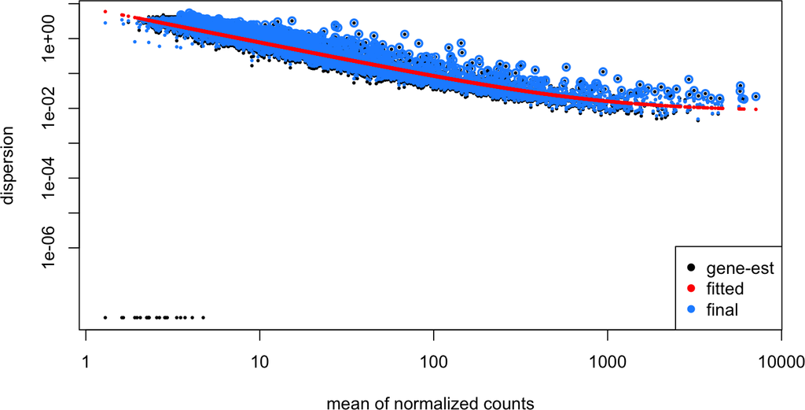

```r
DEres.dispIbr <- DEresIbr[which(mcols(DEresIbr)$betaConv),]
plotDispEsts(DEres.dispIbr)
DEres.dispDuv <- DEresDuv[which(mcols(DEresDuv)$betaConv),]
plotDispEsts(DEres.dispDuv)
```

[output not shown]

This plot looks quite good, as we expect the dispersion values to decrease with increasing mean and that they cluster around the fitted maximum likelihood line. Larger numbers of replicates can estimate the mean and variation more accurately, so yield less shrinkage.

Each black dot is a gene with an associated mean and dispersion value. The red line represents information used across all genes to determine the most likely estimates of dispersion for a given gene expression value. Genes with inaccurately small estimates of variation could yield many false positive genes identified as DE although there are not. Therefore, the original gene-wise dispersion estimates (black dots) are shrunken toward the curve to yield more accurate estimates of dispersion (blue dots), which are used to model the counts for determining the DE genes. Extremely high dispersion values surrounded by blue circles are not shrunken due to the likelihood that the gene may have higher variability than other genes for biological or technical reasons. Reducing the variation could result in false positives.

## 4.2 MA-plot

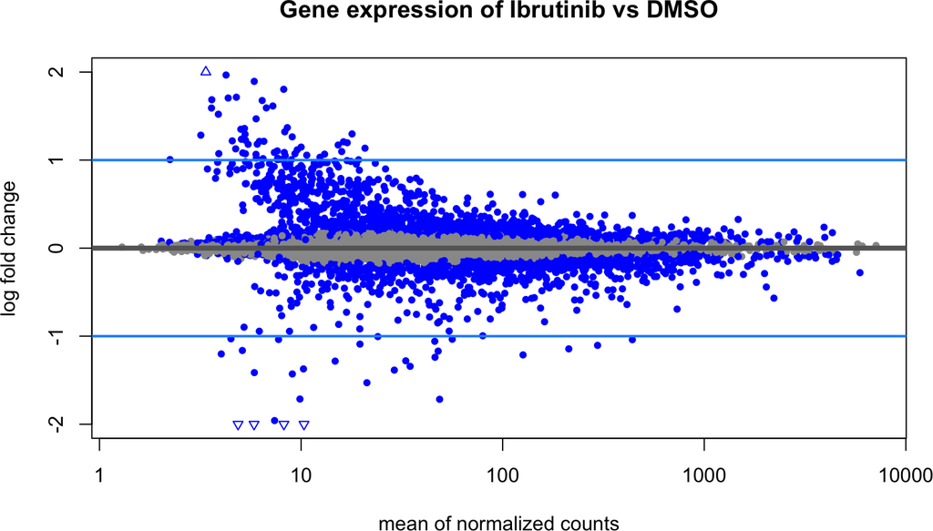

```r
plotMA(allResShrink$Ibrutinib, ylim=c(-2,2), cex=.8, main="Gene expression of Ibrutinib vs DMSO")
abline(h=c(-1,1), col="dodgerblue", lwd=2)
```

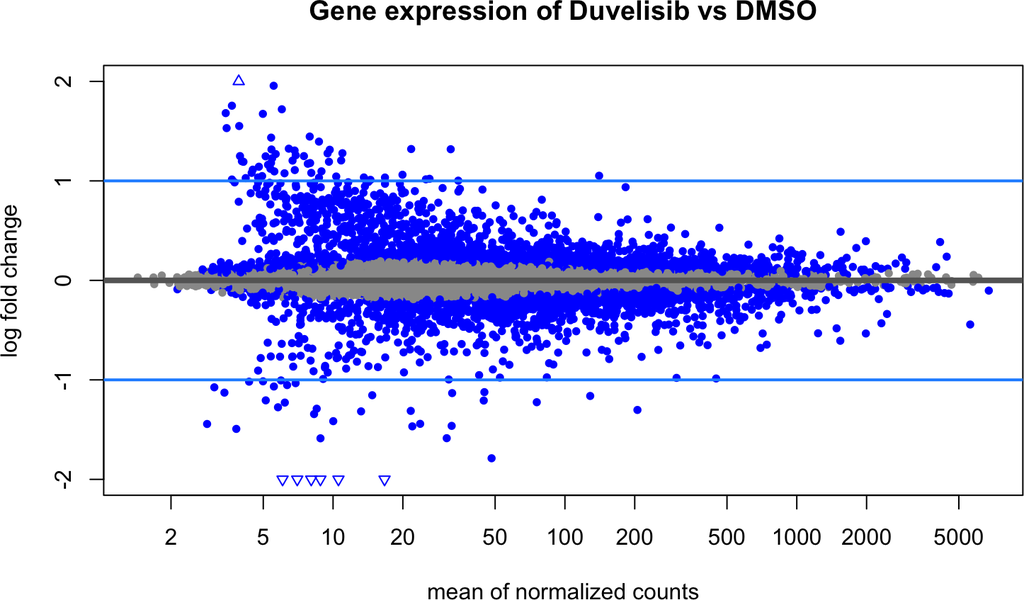

```r
plotMA(allResShrink$Duvelisib, ylim=c(-2,2), cex=.8, main="Gene expression of Duvelisib vs DMSO")
abline(h=c(-1,1), col="dodgerblue", lwd=2)
```

## 4.3 P-value histogram

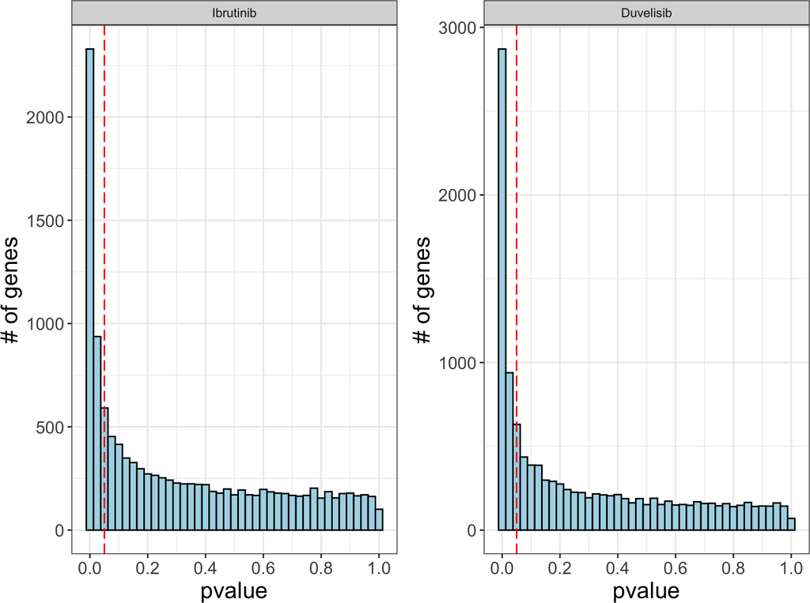

```r
hist_list <- lapply(allResdf, function(res) {
 ggplot(res, aes(x=pvalue)) +
    geom_histogram(fill="lightblue", color="black",binwidth=0.025) +
    geom_vline(xintercept=0.05,color="red",linetype="longdash") +
    facet_wrap(~ treatment) +
    scale_x_continuous(breaks = seq(0,1,by=0.2)) +
    ylab("# of genes") +
    theme(plot.title = element_text(face="bold",hjust=0.5))
})

plot_grid(plotlist=hist_list, ncol=2)
```

## 4.4 Number of significant DE genes

### 4.4.1 Preparation

Function for creating a df with significant up- or downregulated genes

```r
object_names <- names(allResdf)

sig_genes_df <- function(gle, fdr){
  # Create new df with number of sign. genes for each treatment
  genes_df <- setNames(data.frame(matrix(ncol = 2, nrow = 0)),
                         c("treatment", "sig_genes"))
  compare <- match.fun(gle)

  for(df in allResdf){
    n_genes <- filter(df, compare(LFC,0) & padj < fdr) %>%
      summarise(n=length(Ensembl)) %>% pull(n)
    tr <- unique(df$treatment)

    new_row <- c(tr, n_genes)
    genes_df[nrow(genes_df) + 1, ] <- new_row
  }
  genes_df$sig_genes <- as.numeric(genes_df$sig_genes)
  genes_df$treatment <- factor(genes_df$treatment,
                               levels = allTreat)
  return(genes_df)
}
```

Function for plotting number of significant genes for Ibrutinib and Duvelisib

```r
sigDEgenes <- function(df, title){
  plot <- ggplot(df, aes(x=treatment, y=sig_genes)) +
    geom_bar(stat = "identity", color="black", fill="#0C3C9F") +
    theme(axis.text.x = element_text(angle = 90, vjust=0.5, hjust=1)) +
    ylab("# significant DE genes") +
    theme(axis.title.x = element_blank()) +
    ggtitle(title) +
    geom_text(aes(label=sig_genes),vjust=1.5,size=4,color="white")
  return(plot)
}
```

#### 4.4.1.1 5% FDR

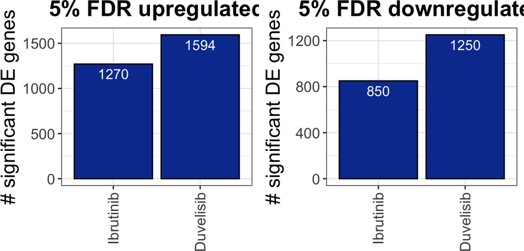

```r
# Upregulated
sig_genes_df_up <- sig_genes_df(gle=">", fdr=0.05)
genes_5FDRup <- sigDEgenes(df=sig_genes_df_up, title="5% FDR upregulated")

# Downregulated
sig_genes_df_down <- sig_genes_df(gle="<", fdr=0.05)
genes_5FDRdown <- sigDEgenes(df=sig_genes_df_down, title="5% FDR downregulated")

plot_grid(genes_5FDRup, genes_5FDRdown, ncol=2)
```

#### 4.4.1.2 10% FDR

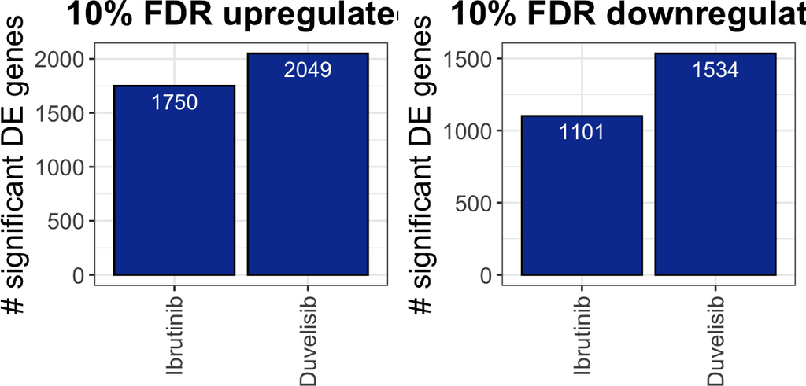

```r
# Upregulated
sig_genes_df_up <- sig_genes_df(gle=">", fdr=0.1)
genes_10FDRup <- sigDEgenes(df=sig_genes_df_up, title="10% FDR upregulated")

# Downregulated
sig_genes_df_down <- sig_genes_df(gle="<", fdr=0.1)
genes_10FDRdown <- sigDEgenes(df=sig_genes_df_down, title="10% FDR downregulated")

plot_grid(genes_10FDRup, genes_10FDRdown, ncol=2)
```

#### 4.4.1.3 25% FDR

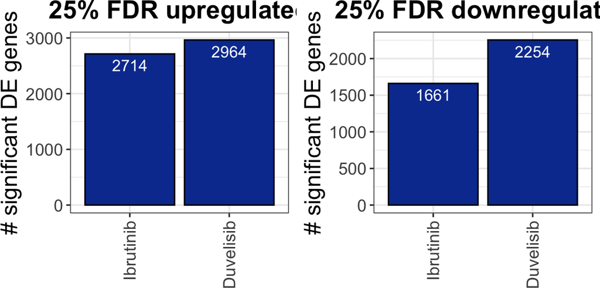

```r
# Upregulated
sig_genes_df_up <- sig_genes_df(gle=">", fdr=0.25)
genes_25FDRup <- sigDEgenes(df=sig_genes_df_up, title="25% FDR upregulated")

# Downregulated
sig_genes_df_down <- sig_genes_df(gle="<", fdr=0.25)
genes_25FDRdown <- sigDEgenes(df=sig_genes_df_down, title="25% FDR downregulated")

plot_grid(genes_25FDRup, genes_25FDRdown, ncol=2)
```

## 4.5 Table of significant associations

Show combined data frame and pre-filter genes

```r
allResdf.combined %>%
  filter_at(vars(padj_Ibr, padj_Duv),
            all_vars(. < 0.2)) %>%
  dplyr::select(Ensembl, symbol, chromosome,
                LFC_Ibr, padj_Ibr, padjBH_Ibr,
                LFC_Duv, padj_Duv,padjBH_Duv) %>%
  mutate_if(is.numeric, formatC, digits=2) %>%
  DT::datatable()
```

|  | Ensembl | symbol | chromosome | LFC_Ibr | padj_Ibr | padjBH_Ibr | LFC_Duv | padj_Duv | padjBH_Duv |
| --- | --- | --- | --- | --- | --- | --- | --- | --- | --- |
| 1 | ENSG00000000938 | FGR | 1 | -0.42 | 3.1e-11 | 3.1e-11 | -0.42 | 2e-08 | 2e-08 |
| 2 | ENSG00000002586 | CD99 | X | -0.19 | 0.0023 | 0.0023 | -0.14 | 0.015 | 0.015 |
| 3 | ENSG00000002587 | HS3ST1 | 4 | 0.28 | 0.0044 | 0.0044 | 0.35 | 0.00031 | 0.00031 |
| 4 | ENSG00000002745 | WNT16 | 7 | -0.25 | 0.06 | 0.06 | -0.72 | 0.0011 | 0.0011 |
| 5 | ENSG00000002919 | SNX11 | 17 | -0.21 | 0.073 | 0.073 | -0.39 | 0.0049 | 0.0049 |
| 6 | ENSG00000004399 | PLXND1 | 3 | 0.37 | 0.00048 | 0.00048 | 0.72 | 3.7e-13 | 3.7e-13 |
| 7 | ENSG00000004455 | AK2 | 1 | -0.11 | 0.11 | 0.11 | -0.2 | 0.0029 | 0.0029 |
| 8 | ENSG00000004700 | RECQL | 12 | -0.16 | 0.0032 | 0.0032 | -0.19 | 0.0007 | 0.0007 |
| 9 | ENSG00000004779 | NDUFAB1 | 16 | -0.26 | 0.0032 | 0.0032 | -0.18 | 0.017 | 0.017 |
| 10 | ENSG00000004799 | PDK4 | 7 | 0.18 | 0.07 | 0.07 | 0.4 | 5.8e-06 | 5.8e-06 |

[output cut: 2859 more lines]

## 4.6 Overlap of differentially expressed genes

### 4.6.1 All genes

Prepare gene lists with all significant genes per treatment

```r
geneList <- lapply(allTreat, function(tr) {
  genes <- filter(allResdf[[tr]], padj < 0.05)$Ensembl
  })
names(geneList) <- allTreat
```

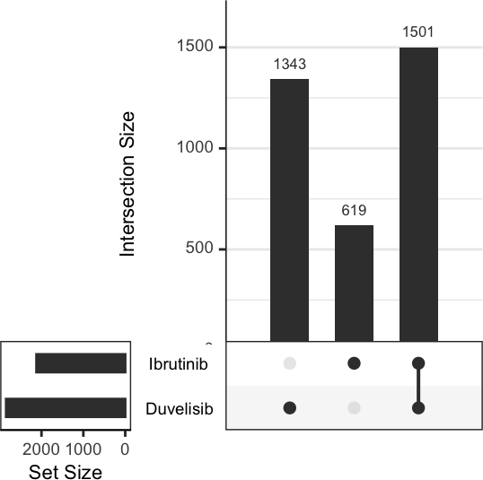

```r
UpSetR::upset(UpSetR::fromList(geneList), nsets = 3)
```

### 4.6.2 Upregulated genes

Retrieve only upregulated genes

```r
geneList.up <- lapply(allTreat, function(tr) {
  allRes.up <- filter(allResdf[[tr]], LFC > 0)
  genes <- filter(allRes.up, padj < 0.05)$Ensembl
  })
names(geneList.up) <- allTreat
```

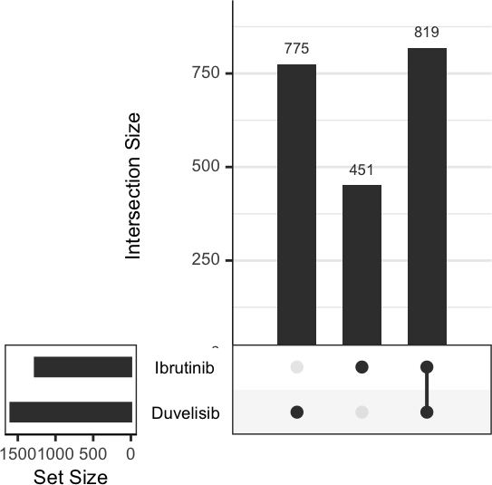

```r
UpSetR::upset(UpSetR::fromList(geneList.up), nsets = 3)
```

Table with most significant upregulated DE genes

```r
allResdf.combined %>%
  filter_at(vars(LFC_Ibr, LFC_Duv),
            all_vars(. > 0)) %>%
  filter_at(vars(padj_Ibr, padj_Duv),
            all_vars(. < 0.2)) %>%
  dplyr::select(Ensembl, symbol, chromosome,
                LFC_Ibr, padj_Ibr, padjBH_Ibr,
                LFC_Duv, padj_Duv, padjBH_Duv) %>%
  mutate_if(is.numeric, formatC, digits=2) %>%
  DT::datatable()
```

|  | Ensembl | symbol | chromosome | LFC_Ibr | padj_Ibr | padjBH_Ibr | LFC_Duv | padj_Duv | padjBH_Duv |
| --- | --- | --- | --- | --- | --- | --- | --- | --- | --- |
| 1 | ENSG00000002587 | HS3ST1 | 4 | 0.28 | 0.0044 | 0.0044 | 0.35 | 0.00031 | 0.00031 |
| 2 | ENSG00000004399 | PLXND1 | 3 | 0.37 | 0.00048 | 0.00048 | 0.72 | 3.7e-13 | 3.7e-13 |
| 3 | ENSG00000004799 | PDK4 | 7 | 0.18 | 0.07 | 0.07 | 0.4 | 5.8e-06 | 5.8e-06 |
| 4 | ENSG00000004948 | CALCR | 7 | 0.07 | 0.051 | 0.051 | 0.08 | 0.13 | 0.13 |
| 5 | ENSG00000005108 | THSD7A | 7 | 0.11 | 0.056 | 0.056 | 0.78 | 0.00038 | 0.00038 |
| 6 | ENSG00000005187 | ACSM3 | 16 | 0.3 | 2.1e-05 | 2.1e-05 | 0.62 | 2.4e-33 | 2.4e-33 |
| 7 | ENSG00000005421 | PON1 | 7 | 0.058 | 0.098 | 0.098 | 0.44 | 0.022 | 0.022 |
| 8 | ENSG00000006071 | ABCC8 | 11 | 0.093 | 0.12 | 0.12 | 0.17 | 0.09 | 0.09 |
| 9 | ENSG00000006125 | AP2B1 | 17 | 0.086 | 0.12 | 0.12 | 0.098 | 0.049 | 0.049 |
| 10 | ENSG00000006283 | CACNA1G | 17 | 0.045 | 0.12 | 0.12 | 0.092 | 0.032 | 0.032 |

[output cut: 1704 more lines]

### 4.6.3 Downregulated genes

Retrieve only downregulated genes

```r
geneList.down <- lapply(allTreat, function(tr) {
  allRes.down <- filter(allResdf[[tr]], LFC < 0)
  genes <- filter(allRes.down, padj < 0.05)$Ensembl
  })
names(geneList.down) <- allTreat
```

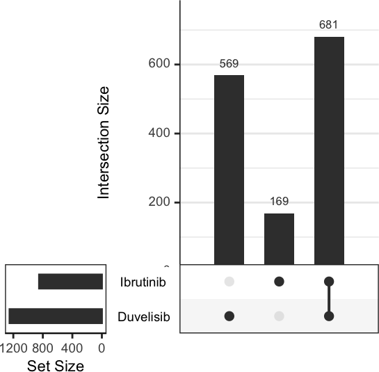

```r
UpSetR::upset(UpSetR::fromList(geneList.down), nsets=3)
```

Table with most significant downregulated DE genes

```r
allResdf.combined %>%
  filter_at(vars(LFC_Ibr, LFC_Duv),
            all_vars(. < 0)) %>%
  filter_at(vars(padj_Ibr, padj_Duv),
            all_vars(. < 0.2)) %>%
  dplyr::select(Ensembl, symbol, chromosome,
                LFC_Ibr, padj_Ibr, padjBH_Ibr,
                LFC_Duv, padj_Duv, padjBH_Duv) %>%
  mutate_if(is.numeric, formatC, digits=2) %>%
  DT::datatable()
```

|  | Ensembl | symbol | chromosome | LFC_Ibr | padj_Ibr | padjBH_Ibr | LFC_Duv | padj_Duv | padjBH_Duv |
| --- | --- | --- | --- | --- | --- | --- | --- | --- | --- |
| 1 | ENSG00000000938 | FGR | 1 | -0.42 | 3.1e-11 | 3.1e-11 | -0.42 | 2e-08 | 2e-08 |
| 2 | ENSG00000002586 | CD99 | X | -0.19 | 0.0023 | 0.0023 | -0.14 | 0.015 | 0.015 |
| 3 | ENSG00000002745 | WNT16 | 7 | -0.25 | 0.06 | 0.06 | -0.72 | 0.0011 | 0.0011 |
| 4 | ENSG00000002919 | SNX11 | 17 | -0.21 | 0.073 | 0.073 | -0.39 | 0.0049 | 0.0049 |
| 5 | ENSG00000004455 | AK2 | 1 | -0.11 | 0.11 | 0.11 | -0.2 | 0.0029 | 0.0029 |
| 6 | ENSG00000004700 | RECQL | 12 | -0.16 | 0.0032 | 0.0032 | -0.19 | 0.0007 | 0.0007 |
| 7 | ENSG00000004779 | NDUFAB1 | 16 | -0.26 | 0.0032 | 0.0032 | -0.18 | 0.017 | 0.017 |
| 8 | ENSG00000005059 | MCUB | 4 | -0.083 | 0.19 | 0.19 | -0.15 | 0.013 | 0.013 |
| 9 | ENSG00000005075 | POLR2J | 7 | -0.14 | 0.064 | 0.064 | -0.13 | 0.11 | 0.11 |
| 10 | ENSG00000006576 | PHTF2 | 7 | -0.16 | 0.013 | 0.013 | -0.19 | 0.00041 | 0.00041 |

[output cut: 1136 more lines]

## 4.7 Volcano plots

Function for creating volcano plot

```r
volcano <- function(res, title){
  plot <- ggplot(res, aes(x=LFC, y=-log10(padj))) +
    geom_vline(xintercept = 0, color="black", linetype="solid", size=0.25) +
    geom_hline(yintercept = -log10(0.01), color="darkgrey", linetype="dashed") +
    geom_hline(yintercept = -log10(0.10), color="darkgrey", linetype="dashed") +
    geom_vline(xintercept = 1, color="darkgrey", linetype="dashed") +
    geom_vline(xintercept =-1, color="darkgrey", linetype="dashed") +
    geom_point(data=res[res$LFC >= 0 & res$padj <= 0.1,],
              color="firebrick3", size=0.9) +
    geom_point(data=res[res$LFC <= 0 & res$padj <= 0.1,],
              color="navy", size=0.9) +
    geom_point(data=res[res$padj >= 0.1,], color="darkgrey", size=0.9) +
    geom_label(data=res[res$padj <= 0.001,], aes(label=symbol),
               label.size=NA, fill=NA, size=2, nudge_y=c(log10(2))) +
    ggtitle(title) +
    theme(plot.title = element_text(hjust=0.5, face="bold"))
  return(plot)
}
```

Remove genes with non-calculated adjusted p-values

```r
allResdf.na<- lapply(allResdf, function(df) {
  df <- df[!is.na(df$padj),]
  })
names(allResdf.na) <- allTreat
```

Show volcano plot for all conditions

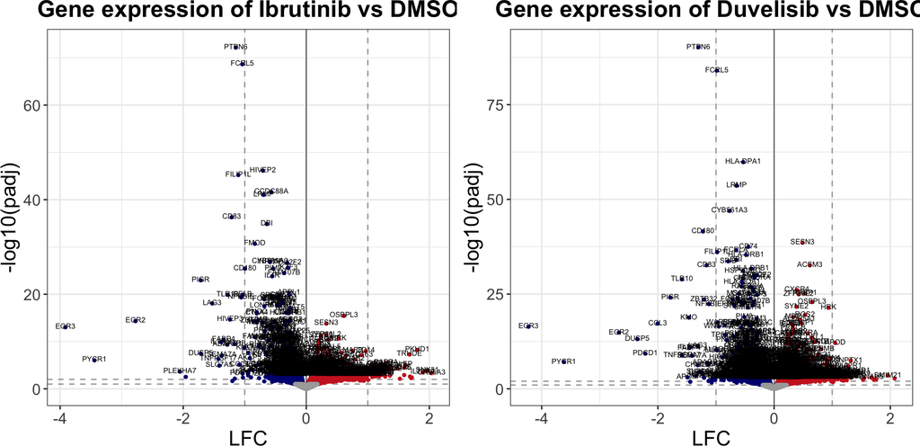

```r
p1 <- volcano(allResdf.na$Ibrutinib,
              title="Gene expression of Ibrutinib vs DMSO")
p2 <- volcano(allResdf.na$Duvelisib,
              title="Gene expression of Duvelisib vs DMSO")
plot_grid(p1, p2, ncol=2)
```